# 23MAP500 Coursework

Last updated: October 19, 2023

## **Introduction**

Capital Bikeshare is a company that offers a bicycle-sharing system for those in Washington DC and its surrounding areas. This project aims to uncover interesting insights about the behavior of users of the system, through a series of research questions that will be answered using data provided by the company. The exploration of this data could be helpful in improving the understanding of how bikes are being used around Washington and ultimately help inform research about how people are travelling through cities, with cycling considered to be an important avenue for how cities can improve their environmental footprint, because it reduces air pollution and traffic congestion (Yang et al. 2019). Furthermore, cycling is proven to be a health-promoting activity and it is hypothesized that substantial health improvements can be made to a population by encouraging it to cycle more frequently (Mizdrak et al. 2019). The data used in this research has been provided in CSV format by Capital Bikeshare, where each row gives details about a bike journey that took place using the service. For example, the first column, called ‘Duration’, gives information about the length of the journey in seconds. Each of these details about a journey can be used to uncover patterns about user behavior and help understand how cycling fits in with the wider topic of how people travel in cities.

## **Data**

The data provided by Capital Bikeshare has been done so with the aim of encouraging analysis by developers, statisticians and more. The data has been published every quarter since 2010 and includes a range of details about every bike journey that occurred using their system during that quarter, but the focus of this research is on the data collected during 2018 and 2019. There are some important features included in the data, such as the duration of each trip, the start date and time of each trip, the end date and time of each trip, the start and end station name of each trip and whether the journey was undertaken by a registered member of the service or a ‘casual’ rider.  
To analyse the data, it first needs to be cleaned. The cleaning process involves handling null values appropriately, ensuring all columns are of an appropriate type, handling errors in the data and ensuring all column names are correctly formatted. First, the necessary R libraries need to be imported, which are useful for efficient loading, cleaning and analysis of the data:

```r
library(conflicted) # the 'conflicted' library is imported to handle errors that arise as a result of different libraries and their functions conflicting with each other
library(here)
library(tidyverse)
library(lubridate)
library(ggrepel)
library(janitor)
```

The data can then be loaded into the notebook using the ‘here’ library, the relative file path and the name of the CSV file:

```r
rides_data_original = read_delim(file = here("data", "rides_2018_2019_extract.csv"), delim = ",", col_names = TRUE)
head(rides_data_original, n = 20)
```

| Duration | Start date | End date | start_station_id | Start station name | end_station_id | End station name | bike_number | member_casual | ride_id | rideable_type | start_lat | start_lng | end_lat | end_lng | is_equity |
| --- | --- | --- | --- | --- | --- | --- | --- | --- | --- | --- | --- | --- | --- | --- | --- |
| 298 | 2019-02-26 07:20:30 | 2019-02-26 07:25:28 | 31214 | 17th & Corcoran St NW | 31213 | 17th & K St NW | W20825 | Member | NA | NA | NA | NA | NA | NA | NA |
| 10734 | 2018-05-26 12:49:54 | 2018-05-26 15:48:48 | 31121 | Calvert St & Woodley Pl NW | 31246 | M St & Pennsylvania Ave NW | W01242 | Member | NA | NA | NA | NA | NA | NA | NA |
| 815 | 2018-04-12 08:06:39 | 2018-04-12 08:20:14 | 31223 | Convention Center / 7th & M St NW | 31235 | 19th St & Constitution Ave NW | W23270 | Member | NA | NA | NA | NA | NA | NA | NA |
| 1846 | 2019-02-18 17:11:53 | 2019-02-18 17:42:39 | 31288 | 4th St & Madison Dr NW | 31247 | Jefferson Dr & 14th St SW | W01089 | Casual | NA | NA | NA | NA | NA | NA | NA |
| 125 | 2018-04-04 07:25:52 | 2018-04-04 07:27:57 | 31052 | Potomac Ave & 35th St S | 31009 | 27th & Crystal Dr | W20124 | Member | NA | NA | NA | NA | NA | NA | NA |
| 305 | 2019-01-06 20:01:52 | 2019-01-06 20:06:57 | 31646 | Maine Ave & 9th St SW | 31108 | 4th & M St SW | W01233 | Member | NA | NA | NA | NA | NA | NA | NA |
| 796 | 2019-10-12 23:14:26 | 2019-10-12 23:27:42 | 31282 | 16th & R St NW | 31102 | 11th & Kenyon St NW | W24183 | Member | NA | NA | NA | NA | NA | NA | NA |
| 835 | 2019-12-23 19:00:19 | 2019-12-23 19:14:14 | 31203 | 14th & Rhode Island Ave NW | 31105 | 14th & Harvard St NW | W24186 | Member | NA | NA | NA | NA | NA | NA | NA |
| 323 | 2019-01-15 22:36:40 | 2019-01-15 22:42:03 | 31089 | Court House Metro / 15th & N Uhle St | 31079 | Lee Hwy & N Cleveland St | W01496 | Member | NA | NA | NA | NA | NA | NA | NA |
| 797 | 2018-04-10 08:22:22 | 2018-04-10 08:35:39 | 31286 | 11th & O St NW | 31257 | 22nd & I St NW / Foggy Bottom | W00955 | Member | NA | NA | NA | NA | NA | NA | NA |

[output cut: 10 more lines]

Upon initial exploration, it seems there are a number of columns that have NA values. If these columns consist of only NA values, they need to be dropped, as there will not be any utility in attempting to uncover any insights using these columns. To check the number of NA values in these columns, a value count for each of the columns needs to be initialized, which counts the number of times each unique value appears in each column:

```r
cols_for_value_counts <- 10:16 # columns 10:16 seemed to contain only NA values

value_counts_10_16 <- rides_data_original %>%
  dplyr::select(all_of(cols_for_value_counts)) %>%
  gather(key = "column", value = "value") %>% # gathers the different column names into one column, so the unique values across all the columns can be counted at once
  count(column, value, sort = TRUE) # counts the number of each unique value for each column

value_counts_10_16
```

| column | value | n |
| --- | --- | --- |
| end_lat | NA | 2602912 |
| end_lng | NA | 2602912 |
| is_equity | NA | 2602912 |
| ride_id | NA | 2602912 |
| rideable_type | NA | 2602912 |
| start_lat | NA | 2602912 |
| start_lng | NA | 2602912 |

The above output shows that through the 10th to 16th columns, there are only NA values. Therefore, these columns will need to be removed from the data set as part of the cleaning process. Next, appropriate data types need to be established for each column. The only column that needs to have its’ data type changed is the ‘Duration’ column, as it needs to be changed from type “Character” to type “Numeric”, due to the column containing a series of numbers. However, the existence of non-numeric values also needs to be checked, as these observations need to be either changed or removed from the data:

```r
non_numeric <-rides_data_original %>%
  dplyr::filter(!grepl("^[0-9]*$", Duration)) # filter to include non-numeric values
non_numeric
```

| Duration | Start date | End date | start_station_id | Start station name | end_station_id | End station name | bike_number | member_casual | ride_id | rideable_type | start_lat | start_lng | end_lat | end_lng | is_equity |
| --- | --- | --- | --- | --- | --- | --- | --- | --- | --- | --- | --- | --- | --- | --- | --- |
| --- | 2018-03-07 18:36:36 | 2018-03-07 18:45:07 | 31613 | Eastern Market Metro / Pennsylvania Ave & 7th St SE | 31614 | 11th & H St NE | W20911 | Member | NA | NA | NA | NA | NA | NA | NA |
| --- | 2018-10-10 07:10:13 | 2018-10-10 07:28:34 | 31258 | Lincoln Memorial | 31282 | 16th & R St NW | W23528 | Member | NA | NA | NA | NA | NA | NA | NA |
| -65345.7410628796 | 2018-10-20 10:14:06 | 2018-10-19 16:05:00 | 31624 | North Capitol St & F St NW | 31624 | North Capitol St & F St NW | W21649 | Casual | NA | NA | NA | NA | NA | NA | NA |
| --- | 2019-07-12 07:53:50 | 2019-07-12 07:59:54 | 31285 | 22nd & P ST NW | 31267 | 17th St & Massachusetts Ave NW | W20189 | Member | NA | NA | NA | NA | NA | NA | NA |
| --- | 2019-01-13 11:58:14 | 2019-01-13 12:04:14 | 31216 | 14th St & New York Ave NW | 31270 | 8th & D St NW | W00082 | Member | NA | NA | NA | NA | NA | NA | NA |
| --- | 2018-05-25 14:52:18 | 2018-05-25 15:10:21 | 31023 | Fairfax Dr & Wilson Blvd | 31314 | 34th & Water St NW | W00233 | Member | NA | NA | NA | NA | NA | NA | NA |
| --- | 2018-06-05 14:09:20 | 2018-06-05 14:11:25 | 31260 | 23rd & E St NW | 31297 | Virginia Ave & 25th St NW | W23139 | Member | NA | NA | NA | NA | NA | NA | NA |
| -41861.0563921928 | 2018-03-16 18:22:02 | 2018-03-16 06:44:20 | 31620 | 5th & F St NW | 31614 | 11th & H St NE | W01270 | Member | NA | NA | NA | NA | NA | NA | NA |
| --- | 2018-01-23 08:46:11 | 2018-01-23 08:53:52 | 31248 | Smithsonian-National Mall / Jefferson Dr & 12th St SW | 31284 | 18th & C St NW | W00163 | Member | NA | NA | NA | NA | NA | NA | NA |
| --- | 2019-04-22 08:45:11 | 2019-04-22 09:02:06 | 31091 | Joyce St & 16th St S | 31012 | Clark St & 26th St S | W00841 | Casual | NA | NA | NA | NA | NA | NA | NA |

[output cut: 9990 more lines]

There are at least 10,000 rows where the value in the ‘Duration’ column does not correspond to a positive integer, i.e. the values are either negative or missing. To fix the missing values, the ‘Start date’ and ‘End date’ columns can be used to calculate the actual duration of the journey in seconds. For those rows where there are negative duration values, these observations will have to be removed, as they represent inaccurate data and make up less than 0.03% of the total data, meaning the removal of these values will not significantly alter the analysis of the data. Another potential solution to handling these negative duration values could have been to swap the ‘Start date’ and ‘End date’ values for these rows, as the end date being before the start date was the cause of the negative values. However, there is no way to decipher whether this would have given an accurate duration, as the end date or start date may simply have been inputted incorrectly with the wrong values, rather than having been swapped around in the initial data. Finally, there are a few column names that need to be cleaned, as they should be in the ‘snake_case’ format, which is the convention for variable and feature names in computer programming. All of the data cleaning steps mentioned can be performed using a pipe:

```r
rides_data_cleaned <- rides_data_original %>%
  select(-10:-16) %>% # remove NA filled columns
  mutate(
    Duration = as.numeric(difftime(`End date`, `Start date`, units = "secs")) # change the data type to numeric and calculate the duration of the journey in seconds, which will fill in the blank rows
  ) %>%
   dplyr::filter(Duration >= 0) %>% # Remove rows where duration is negative
  clean_names() # clean column names
```

```r
head(rides_data_cleaned, n = 10)
```

| duration | start_date | end_date | start_station_id | start_station_name | end_station_id | end_station_name | bike_number | member_casual |
| --- | --- | --- | --- | --- | --- | --- | --- | --- |
| 298 | 2019-02-26 07:20:30 | 2019-02-26 07:25:28 | 31214 | 17th & Corcoran St NW | 31213 | 17th & K St NW | W20825 | Member |
| 10734 | 2018-05-26 12:49:54 | 2018-05-26 15:48:48 | 31121 | Calvert St & Woodley Pl NW | 31246 | M St & Pennsylvania Ave NW | W01242 | Member |
| 815 | 2018-04-12 08:06:39 | 2018-04-12 08:20:14 | 31223 | Convention Center / 7th & M St NW | 31235 | 19th St & Constitution Ave NW | W23270 | Member |
| 1846 | 2019-02-18 17:11:53 | 2019-02-18 17:42:39 | 31288 | 4th St & Madison Dr NW | 31247 | Jefferson Dr & 14th St SW | W01089 | Casual |
| 125 | 2018-04-04 07:25:52 | 2018-04-04 07:27:57 | 31052 | Potomac Ave & 35th St S | 31009 | 27th & Crystal Dr | W20124 | Member |
| 305 | 2019-01-06 20:01:52 | 2019-01-06 20:06:57 | 31646 | Maine Ave & 9th St SW | 31108 | 4th & M St SW | W01233 | Member |
| 796 | 2019-10-12 23:14:26 | 2019-10-12 23:27:42 | 31282 | 16th & R St NW | 31102 | 11th & Kenyon St NW | W24183 | Member |
| 835 | 2019-12-23 19:00:19 | 2019-12-23 19:14:14 | 31203 | 14th & Rhode Island Ave NW | 31105 | 14th & Harvard St NW | W24186 | Member |
| 323 | 2019-01-15 22:36:40 | 2019-01-15 22:42:03 | 31089 | Court House Metro / 15th & N Uhle St | 31079 | Lee Hwy & N Cleveland St | W01496 | Member |
| 797 | 2018-04-10 08:22:22 | 2018-04-10 08:35:39 | 31286 | 11th & O St NW | 31257 | 22nd & I St NW / Foggy Bottom | W00955 | Member |

The ‘rides_data_cleaned’ tibble shows an updated version of the data, where unnecessary columns have been removed, column data types are more appropriate and column names are more conventional.

## **Questions**

1. *What are the differences in journey length between casual and member riders?*

The quantitative differences in journey length between casual and member riders can be calculated using the ‘duration’ and ‘member_casual’ columns. As these variables provide information about the duration of a journey the rider undertook in seconds, as well as whether the rider was a member of the system or a casual rider, the data in them can be used to perform calculations which give the summary statistics for each member type for the duration of their journeys. Understanding the differences between member and casual riders could be useful for marketing purposes, as, for example, casual riders may be tempted to become members if their journey lengths are similar to those of members anyway, which would mean they are paying more despite travelling as much.

2. *What are the monthly trends in the number of different bikes used?*

The monthly trends in the number of different bikes used can be extrapolated from the data by initially using the ‘start_date’ column, which represents the date and time at which the journey began. Using this variable, the year and month the journey took place can be further extracted. The ‘bike_number’ variable will also be useful, as it can be used to differentiate between different bikes and ultimately calculate the number of bikes used in a given year. Understanding how the number of different bikes used through the Capital Bikeshare service has changed over time can give an indication of how the service is growing, the rate at which it is growing and this could potentially even be used to perform predictive analysis in the future, for example, to predict how many bikes will be demanded at a specific point in time. More bikes being used would also indicate more people are choosing to cycle, rather than use cars, which could lead to further positive impacts on the city, in terms of both the environment and how much exercise people are getting.

3. *How much revenue is Capital Bikeshare making per month from casual riders?*

To calculate the revenue made by Capital Bikeshare in a given month from casual riders, the ‘start_date’ column can again be used to split the data into the different months. Using the pricing structure outlined on the Capital Bikeshare website in conjunction with the ‘member_casual’ column, the total revenue generated during each bike ride for a casual rider can be calculated. Understanding how much revenue is generated per month by casual riders could again, help with marketing strategy, as, for example, if there is a strong upward trend in the amount of revenue being generated from casual riders, there may be utility in focusing advert campaigns to casual riders. Unfortunately, an accurate trend of the total revenue generated from member riders per month cannot be uncovered, as the same member may have undertaken several journeys, but the revenue gained from their subscription would only occur once. There is no way to distinguish between different members from the data, so the number of different members that undertook a journey within a month cannot be calculated.

4. *What were the seasonal patterns in the number of different journey duration types?*

Some bike journeys are of a different type to to others with regards to how long they last, and to understand how the different seasons correlate with increasing or decreasing numbers of different journey duration types, the different journey duration types first need to be established. If a small journey is defined as a journey lasting less than 10 minutes, a medium journey is defined as a journey which lasted 10 minutes to less than 30 minutes, a long journey is defined as a journey which lasted 30 minutes to less than 60 minutes and a very long journey as a journey which lasted 60 minutes or more, the ‘duration’ variable can be used to categorize each journey into a ‘journey_type’ variable. The ‘start_date’ variable can also be used to categorize each journey by the season it took place in. Understanding the journey types that riders are taking across the different seasons can be helpful in a few ways. First, Capital Bikeshare can use this knowledge to optimally manage resources. For example, if there are more ‘long’ or ‘very long’ journeys occurring during the summer, it may be useful to plant more bikes at docking stations during this time period, if it is known the bikes will be gone for longer. Understanding seasonal trends can also help with pricing strategies. For example, discounts could be offered during periods where riders tend to take shorter journeys, which may encourage riders to continue taking longer journeys.

5. *What are the most popular start and end stations for each of the member types?*

To operationalise this question, the ‘start_station_name’ variable, the ‘end_station_name’ variable, as well as the ‘member_casual’ variable can be used. The data can be filtered twice, so only rows with ‘Casual’ and then ‘Member’ riders are available. The filtered data can then be used to calculate the frequency at which each starting and ending station occurred for each rider type. It is important to have an idea of where riders are beginning and ending their journey most frequently, as these stations will need the most bikes and stations to dock bikes, because more people are initially collecting their bikes from there and leaving their bikes in those stations.

## **Analysis**

### Question 1

The ‘rides_data_cleaned’ tibble can be filtered and summarized to give the statistics of the duration variable, which gives a good indication of how the journey durations vary between the rider types:

```r
print(summary(rides_data_cleaned%>%dplyr::filter(member_casual=="Member")%>%select(duration)))
```

```
##     duration
##  Min.   :    4
##  1st Qu.:  363
##  Median :  604
##  Mean   :  840
##  3rd Qu.:  984
##  Max.   :86289
```

```r
cat("\n\n")
```

```r
print(summary(rides_data_cleaned%>%dplyr::filter(member_casual=="Casual")%>%select(duration)))
```

```
##     duration
##  Min.   :   60
##  1st Qu.:  900
##  Median : 1470
##  Mean   : 2408
##  3rd Qu.: 2640
##  Max.   :88511
```

The summaries above indicate casual riders tend to have longer journey lengths than member riders. However, side by side box plots of the journey durations for casual and member riders will give an appropriate visual aid to help interpret the difference in journey length between the two rider types. Due to how the data is skewed and there being outliers, where the durations are significantly larger than the third quartlies for both casual and member riders, a log transformation of the duration column will need to be implemented, so that the box plots are readable:

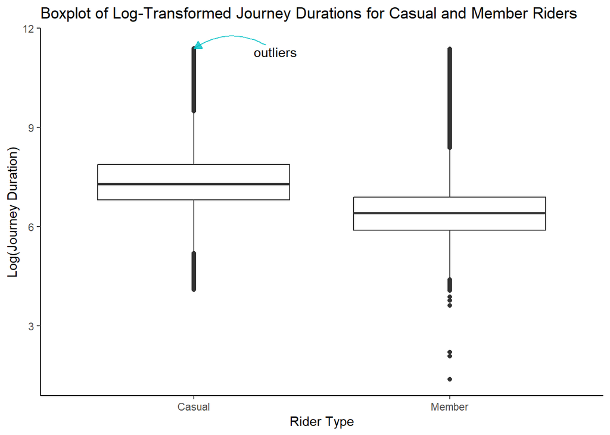

Fig.1

```r
rides_data_cleaned_log_duration <- rides_data_cleaned %>%
  mutate(duration = log(duration))

outliers <- boxplot.stats(rides_data_cleaned_log_duration$duration)$out # create a list of all the outliers

member_casual_boxplots <- ggplot(rides_data_cleaned_log_duration, aes(x = member_casual, y = duration)) +
  geom_boxplot() +
  labs(x = "Rider Type", y = "Log(Journey Duration)") +
  ggtitle("Boxplot of Log-Transformed Journey Durations for Casual and Member Riders")  +
  theme(
    panel.grid.major.x = element_blank(),
    panel.grid.minor.x = element_blank(),
    panel.grid.major.y = element_line(colour = "grey80"),
    panel.grid.minor.y = element_blank(),
    panel.background   = element_blank()
  ) +
   annotate(
     geom = "text",
     x = 1.32,
     y = max(outliers) - 0.1,
     label = 'outliers'
   ) +
   annotate(                         # add arrow
    geom      = "curve",
    x         = 1.28,
    y         = 11.5,
    xend      = 1,
    yend      = max(outliers),
    curvature = 0.3,
    arrow     = arrow(type = "closed", length = unit(2.5, "mm")),
    alpha     = 0.8,
    colour    = "#00BFC4"
  ) +
  theme_classic()


member_casual_boxplots
```

Figure 1 shows box plots that give a visual representation of how the summary statistics, including the median, the lower quartile and the upper quartile, for casual and member riders differ. The plots demonstrate that casual members tend to have a longer journey duration than member riders. The inference that casual riders tend to have a longer journey duration than member riders can be further examined by calculating the mean journey duration across the two rider types:

```r
avg_durations <- rides_data_cleaned %>%
  group_by(member_casual) %>%
  summarise(mean(duration))
avg_durations
```

| member_casual | mean(duration) |
| --- | --- |
| Casual | 2408.3778 |
| Member | 840.0413 |

The mean journey duration for casual riders is almost three times greater than that of member riders, further solidifying the case that casual riders have a longer journey duration than member riders. Casual riders taking longer journeys than member riders is a slightly surprising finding, as it may be expected for them to be taking shorter journeys, due to having to pay more per minute riding. One potential reason for such a finding could be that casual riders tend to use the service less frequently, and only do so as a form of leisure, whereas member riders may use the subscription they pay for to make daily trips to work or school, for example. Therefore, casual riders may be less wary of the time they are spending riding the bikes and be more likely to spend a greater amount of time on a journey.

### Question 2

By extracting the month and year form the ‘start_date’ column and storing this information in a new column, the number of different bikes used during that month and year can be calculated:

```r
rides_data_year_month_extracted <- rides_data_cleaned %>%
  mutate(month_year = format(start_date, format = "%b %y")) # extract month and year from start_date and store in 'month_year' column

num_unique_bikes <- rides_data_year_month_extracted %>%
  group_by(month_year) %>%
  summarize(num_bikes_used_in_month = n_distinct(bike_number)) %>% # count the number of distinct bikes used in each month
  mutate(month_year = as.Date(paste("01", month_year), format = "%d %b %y")) %>% # format month_year column to a date format, so the new tibble can be arranged in the correct date order
  arrange(month_year) %>%
  mutate(month_year = format(month_year, format = "%b %y")) # change back to original format

num_unique_bikes
```

| month_year | num_bikes_used_in_month |
| --- | --- |
| Jan 18 | 3860 |
| Feb 18 | 3852 |
| Mar 18 | 4083 |
| Apr 18 | 4247 |
| May 18 | 4235 |
| Jun 18 | 4202 |
| Jul 18 | 4166 |
| Aug 18 | 4036 |
| Sep 18 | 4068 |
| Oct 18 | 3829 |

[output cut: 14 more lines]

The above information can be represented visually, using a bar chart, where each bar represents a specific month in the time frame and the height of the bar represents the number of different bikes that were used in that month. A bar chart makes it clear from a visual perspective which months had the greatest number of bikes used, as they will be the tallest and which months had the lowest number of bikes uses, as they will be the shortest:

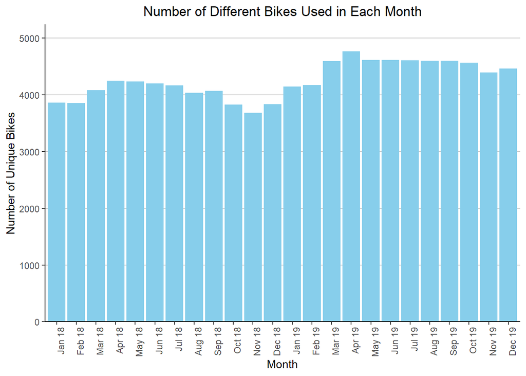

Fig.2

```r
num_unique_bikes$month_year <- factor(num_unique_bikes$month_year, levels = unique(num_unique_bikes$month_year)) # convert the 'month_year' column into a factor, so the bar chart retains the order of the column

ggplot(num_unique_bikes, aes(x = month_year, y = num_bikes_used_in_month)) +
  geom_bar(stat = "identity", fill = "skyblue") +
  labs(x = "Month", y = "Number of Unique Bikes") +
  ggtitle("Number of Different Bikes Used in Each Month") +
  theme_classic() +
  scale_y_continuous(expand = expansion(mult = c(0, 0.1)), limits = c(0, max(num_unique_bikes$num_bikes_used_in_month))) +
  theme(axis.text.x = element_text(angle = 90, hjust = 1),  # Rotate x-axis labels
        plot.title = element_text(hjust = 0.5),
        panel.grid.major.x = element_blank(),
    panel.grid.minor.x = element_blank(),
    panel.grid.major.y = element_line(colour = "grey80"),
    panel.grid.minor.y = element_blank(),
    panel.background   = element_blank()
  )
```

There are a few trends which are shown on the bar chart of ‘Number of Different Bikes Used in Each Month’. First, the overall monthly trend is one of an increasing number of different bikes being used with time. For example, in January 2018, 3860 different bikes were used and in December 2019, that number had risen by approximately 16% to 4460 different bikes having been used, with the highest number of unique bikes being used in April 2019, at 4766 bikes. During both 2018 and 2019, the spring and summer months represented the two seasons where the most number of unique bikes were used, whereas in both years, the autumn and winter months represented the seasons where there were a fewer number of unique bikes used relative to the rest of the year. The key take away from the patterns uncovered in the bar chart is that with time, Capital Bikeshare will potentially need more bikes on the streets, if the demand for different bikes continues on an upward trajectory. Seasonal changes in the demand for different bikes also have to be considered, as during the autumn and winter months, when it is colder and less appealing to ride a bike, the necessity for a greater number of different bikes will be reduced, and therefore, these time periods could be used as an optimal time to make any physical adjustments to the bikes that the company may have planned and take them off the streets.

### Question 3

To analyse how much revenue is generated from casual riders per month, the ‘rides_data_year_month_extracted’ tibble can be filtered to contain only the casual rider rows. Then, using the prcing strategy outlined on the Capital Bikeshare website, where a single ride on a classic bike costs $0.5 per minute, as well as a $1 charge for unlocking the bike, the revenue generated for a journey can be calculated.

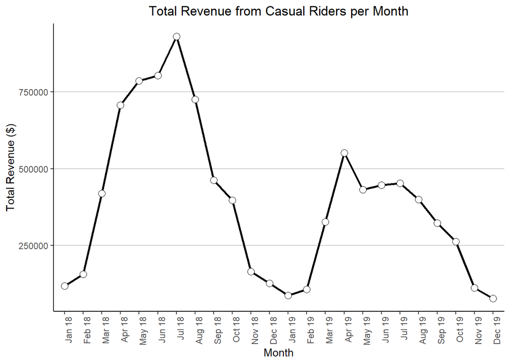

Fig. 3

```r
revenue_per_month_from_casual <- rides_data_year_month_extracted %>%
  dplyr::filter(member_casual == "Casual") %>%
  mutate(journey_revenue = ((duration / 60) * 0.5) + 1) %>%
  group_by(month_year) %>%
  summarise(total_rev = sum(journey_revenue)) %>% # sum the total revenue generated for each month
  mutate(month_year = reorder(month_year, as.Date(paste("01", month_year), format = "%d %b %y"))) # order the tibble by month and year using an appropriate date format

ggplot(revenue_per_month_from_casual, aes(x = month_year, y = total_rev, group = 1)) +
  geom_line(size = 1.05) +
  geom_point(size = 3, shape = 21, fill = "white", color = "black") +
  labs(x = "Month", y = "Total Revenue ($)") +
  ggtitle("Total Revenue from Casual Riders per Month") +
  theme_classic() +
  theme(axis.text.x = element_text(angle = 90, hjust = 1),
        plot.title = element_text(hjust = 0.5),
        panel.grid.major.x = element_blank(),
    panel.grid.minor.x = element_blank(),
    panel.grid.major.y = element_line(colour = "grey80"),
    panel.grid.minor.y = element_blank(),
    panel.background   = element_blank()
  )
```

The total revenue generated from casual riders appears to peak during the spring and summer months for both years. During the winter and autumn months, the revenue generated experiences a steep drop off for both years, indicating there are not only a smaller number of journeys undertaken by casual riders during these months, but that the journeys that are being made are of less duration. The overall trend across the whole time frame is that of a decreasing total revenue generated from casual riders. As question 2 uncovered, the overall number of different bikes being used has increased over time, which would actually have a more positive impact on total revenue, so could indicate that riders that were casual during earlier parts of the time frame may have purchased memberships of the bike sharing service and are now registered members, so any revenue they generate would not be counted toward the revenue generated from casual riders any more.  
It is important to state that there may be inaccuracies with regards to how the revenue generated from a journey was initially calculated, as it was assumed that all casual riders chose the ‘Single ride’ option, although there is also an option for a ‘Day pass’, which is likely to have also been chosen by casual riders. This would have changed the revenue generated from a journey, as any journey below 45 minutes would have only incurred the original cost of $8 for the day pass and any journey lasting longer than 45 minutes would have incurred the additional cost of $0.5 for the period after 45 minutes.

### Question 4

Different functions can be applied to all of the rows in the data to generate new variables, which categorize the season the journey took place in and categorize which duration type a journey was:

```r
categorize_season <- function(start_date) {
  month <- as.POSIXlt(start_date)$mon + 1 # function to categorize which season a journey took place in
  if (month %in% c(12, 1, 2)) {
    return("winter")
  } else if (month %in% c(3, 4, 5)) {
    return("spring")
  } else if (month %in% c(6, 7, 8)) {
    return("summer")
  } else {
    return("autumn")
  }
}

categorize_journey_type <- function(duration) {
  duration_minutes <- duration / 60  # categorizes what type of journey duration a journey was
  if (duration_minutes < 10) {
    return("Short Journey (< 10 mins)")
  } else if (duration_minutes < 30) {
    return("Medium-Length Journey(10-30 mins)")
  } else if (duration_minutes < 60) {
    return("Long Journey (30-60 mins)")
  } else {
    return("Very long Journey (> 60 mins)")
  }
}
```

A new tibble can now be created, which contains the new variables that applyting the two functions to all of the rows in the original tibble will create:

```r
rides_data_seasons_journey_type <- rides_data_cleaned %>%
  mutate(season = sapply(start_date, categorize_season),
         journey_type = sapply(duration, categorize_journey_type), # applying the functions to all rows so new variables are created
         year = format(start_date, format = "%Y"))

head(rides_data_seasons_journey_type, n = 10)
```

| duration | start_date | end_date | start_station_id | start_station_name | end_station_id | end_station_name | bike_number | member_casual | season | journey_type | year |
| --- | --- | --- | --- | --- | --- | --- | --- | --- | --- | --- | --- |
| 298 | 2019-02-26 07:20:30 | 2019-02-26 07:25:28 | 31214 | 17th & Corcoran St NW | 31213 | 17th & K St NW | W20825 | Member | winter | Short Journey (< 10 mins) | 2019 |
| 10734 | 2018-05-26 12:49:54 | 2018-05-26 15:48:48 | 31121 | Calvert St & Woodley Pl NW | 31246 | M St & Pennsylvania Ave NW | W01242 | Member | spring | Very long Journey (> 60 mins) | 2018 |
| 815 | 2018-04-12 08:06:39 | 2018-04-12 08:20:14 | 31223 | Convention Center / 7th & M St NW | 31235 | 19th St & Constitution Ave NW | W23270 | Member | spring | Medium-Length Journey(10-30 mins) | 2018 |
| 1846 | 2019-02-18 17:11:53 | 2019-02-18 17:42:39 | 31288 | 4th St & Madison Dr NW | 31247 | Jefferson Dr & 14th St SW | W01089 | Casual | winter | Long Journey (30-60 mins) | 2019 |
| 125 | 2018-04-04 07:25:52 | 2018-04-04 07:27:57 | 31052 | Potomac Ave & 35th St S | 31009 | 27th & Crystal Dr | W20124 | Member | spring | Short Journey (< 10 mins) | 2018 |
| 305 | 2019-01-06 20:01:52 | 2019-01-06 20:06:57 | 31646 | Maine Ave & 9th St SW | 31108 | 4th & M St SW | W01233 | Member | winter | Short Journey (< 10 mins) | 2019 |
| 796 | 2019-10-12 23:14:26 | 2019-10-12 23:27:42 | 31282 | 16th & R St NW | 31102 | 11th & Kenyon St NW | W24183 | Member | autumn | Medium-Length Journey(10-30 mins) | 2019 |
| 835 | 2019-12-23 19:00:19 | 2019-12-23 19:14:14 | 31203 | 14th & Rhode Island Ave NW | 31105 | 14th & Harvard St NW | W24186 | Member | winter | Medium-Length Journey(10-30 mins) | 2019 |
| 323 | 2019-01-15 22:36:40 | 2019-01-15 22:42:03 | 31089 | Court House Metro / 15th & N Uhle St | 31079 | Lee Hwy & N Cleveland St | W01496 | Member | winter | Short Journey (< 10 mins) | 2019 |
| 797 | 2018-04-10 08:22:22 | 2018-04-10 08:35:39 | 31286 | 11th & O St NW | 31257 | 22nd & I St NW / Foggy Bottom | W00955 | Member | spring | Medium-Length Journey(10-30 mins) | 2018 |

Grouping the new tibble by the ‘journey_type’, ‘season’ and ‘year’ variables, the number of times each journey type occurred during a season can be calculated fo 2018 and 2019:

```r
num_journey_types_per_season <-  rides_data_seasons_journey_type %>%
  group_by(journey_type, season, year) %>%
  summarize(count = n(), .groups = 'drop')

order_of_journey_type <- c("Short Journey (< 10 mins)", "Medium-Length Journey(10-30 mins)", "Long Journey (30-60 mins)", "Very long Journey (> 60 mins)")

num_journey_types_per_season_ordered <- num_journey_types_per_season %>%
  mutate(journey_type = factor(journey_type, levels = order_of_journey_type)) %>%
  arrange(journey_type) # arrange the tibble so that it is ordered by the length of the journey types

num_journey_types_per_season_ordered
```

| journey_type | season | year | count |
| --- | --- | --- | --- |
| Short Journey (< 10 mins) | autumn | 2018 | 147918 |
| Short Journey (< 10 mins) | autumn | 2019 | 155906 |
| Short Journey (< 10 mins) | spring | 2018 | 142495 |
| Short Journey (< 10 mins) | spring | 2019 | 145101 |
| Short Journey (< 10 mins) | summer | 2018 | 170942 |
| Short Journey (< 10 mins) | summer | 2019 | 161677 |
| Short Journey (< 10 mins) | winter | 2018 | 103882 |
| Short Journey (< 10 mins) | winter | 2019 | 93211 |
| Medium-Length Journey(10-30 mins) | autumn | 2018 | 147139 |
| Medium-Length Journey(10-30 mins) | autumn | 2019 | 161824 |

[output cut: 22 more lines]

The above tibble can be demonstrated visually, providing an easier format to analyse the patterns in how the number of the different journey duration types change from season to season:

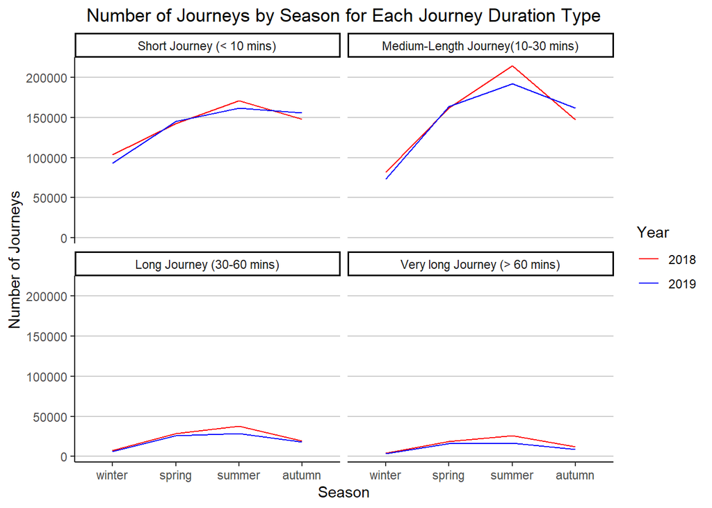

Fig. 4

```r
ggplot(num_journey_types_per_season_ordered, aes(x = season, y = count, group = year, color = year)) +
  geom_line() +
  facet_wrap(~journey_type) +
  scale_x_discrete(limits = c("winter", "spring", "summer", "autumn")) +  # put seasons in order
  labs(x = "Season", y = "Number of Journeys", color = "Year") +
  scale_color_manual(values = c("2018" = "red", "2019" = "blue")) +
  ggtitle("Number of Journeys by Season for Each Journey Duration Type") +
  theme_classic() +
theme(plot.title = element_text(hjust = 0.5),
      panel.grid.major.x = element_blank(),
    panel.grid.minor.x = element_blank(),
    panel.grid.major.y = element_line(colour = "grey80"),
    panel.grid.minor.y = element_blank(),
    panel.background   = element_blank()
  )
```

There are a few key insights to extrapolate from figure 4. First, for all of the different journey duration types, the highest number of journeys occur during the summer and the lowest number of journeys occurs during the winter, for both 2018 and 2019. Medium journey lengths are, in general, the most popular, meaning the most frequent journey duration users undertake is between 10 and 30 minutes. During the winter in both 2018 and 2019, small journeys were the most frequent journey types, indicating users prefer to keep their journeys short whilst it is coldest. Journeys lasting longer than 30 minutes, as indicated by the graphs for ‘Long Journey’ and ‘Very long Journey’, are less popular amongst users, indicating users prefer shorter journeys across Washington. Perhaps bike riders in Washington who tend to travel for durations of over 30 minutes are more likely to own their own bikes, as they are able to choose more appropriate physical attributes of the bike that are best suited for those longer bike journeys. These findings could be used to encourage users to take more very long length journeys, potentially by reducing the price paid per minute after the 60th minute of a journey. Not only could this help boost revenue for Capital Bikeshare as relatively few journeys of this duration type are being made anyway, but may also lead to people cycling for longer in Washington, in turn, helping the population increase the amount of exercise it’s performing.

### Question 5

The decision was made to use the top 5 most popular starting and ending station for the upcoming figures, as a greater number of stations would have led to figures that were more difficult to read and slightly cluttered.  
Filtering the data twice to only contain ‘casual’ and ‘member’ rider rows, before grouping by the ‘start_station_name’ column and summarizing with the count function will calculate the number of times a value in the ‘start_station_name’ column appears for the filtered rows:

```r
top_5_casual_starting <- rides_data_cleaned %>%
  dplyr::filter(member_casual == "Casual") %>%
  group_by(start_station_name) %>%
  summarize(count = n()) %>% # calculate the frequency of a start station
  top_n(5, count) %>% # use only the top 5 most popular start stations
  arrange(desc(count))

top_5_member_starting <- rides_data_cleaned %>%
  dplyr::filter(member_casual == "Member") %>%
  group_by(start_station_name) %>%
  summarize(count = n()) %>%
  top_n(5, count) %>%
  arrange(desc(count))


top_start_stations_member_casual <- rbind(
  mutate(top_5_casual_starting, member_type = "Casual"),
  mutate(top_5_member_starting, member_type = "Member") # merge the filtered tibbles together
)
```

A stacked bar chart, where different colours represent the different starting stations and the size of the colour depicts the number of times that station was a starting station for its’ rider group, provides a visual aid to help understand which stations were the most popular starting stations:

[figure not shown]

Fig. 5

```r
selected_colour_palette <- c("#A51122", "#EDA92B", "#CCE283", "#8C6300", "#91C9C2", "#938DBB", "#CA69AF", "#2B2B21", "#01436C", "#104B00")

ggplot(top_start_stations_member_casual, aes(x = member_type, y = count, fill = start_station_name)) +
  geom_bar(stat = "identity") +
  labs(x = "Member Type", y = "Count of Rides") +
  ggtitle("Top 5 Most Popular Start Stations for Casual and Member Riders") +
  scale_fill_manual(values = selected_colour_palette) +
  theme_classic() +
  theme(plot.title = element_text(hjust = 0.5),
        panel.grid.major.x = element_blank(),
    panel.grid.minor.x = element_blank(),
    panel.grid.major.y = element_line(colour = "grey80"),
    panel.grid.minor.y = element_blank(),
    panel.background   = element_blank()
  ) +
  scale_y_continuous(labels = scales::comma)
```

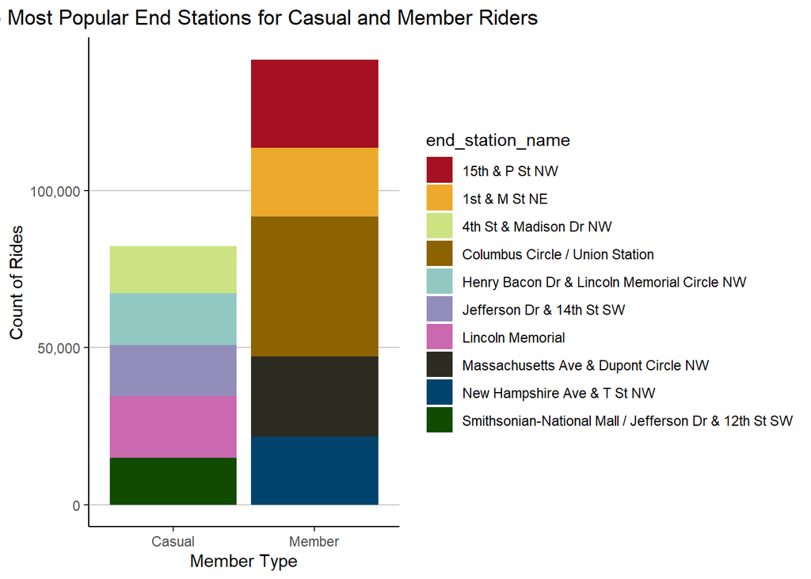

Fig. 6

```r
top_5_casual_ending <- rides_data_cleaned %>%
  dplyr::filter(member_casual == "Casual") %>%
  group_by(end_station_name) %>%
  summarize(count = n()) %>%
  top_n(5, count) %>%
  arrange(desc(count))

top_5_member_ending <- rides_data_cleaned %>%
  dplyr::filter(member_casual == "Member") %>%
  group_by(end_station_name) %>%
  summarize(count = n()) %>%
  top_n(5, count) %>%
  arrange(desc(count))


top_end_stations_member_casual <- rbind(
  mutate(top_5_casual_ending, member_type = "Casual"),
  mutate(top_5_member_ending, member_type = "Member")
)

ggplot(top_end_stations_member_casual, aes(x = member_type, y = count, fill = end_station_name)) +
  geom_bar(stat = "identity") +
  labs(x = "Member Type", y = "Count of Rides") +
  ggtitle("Top 5 Most Popular End Stations for Casual and Member Riders") +
  scale_fill_manual(values = selected_colour_palette) +
  theme_classic() +
  theme(plot.title = element_text(hjust = 0.5),
        panel.grid.major.x = element_blank(),
    panel.grid.minor.x = element_blank(),
    panel.grid.major.y = element_line(colour = "grey80"),
    panel.grid.minor.y = element_blank(),
    panel.background   = element_blank()
  ) +
  scale_y_continuous(labels = scales::comma)
```

The bar chart for the most popular ending stations between casual and member riders shows there is significant crossover between the most frequent start stations and most frequent end stations. For example, the 5 most popular starting stations for casual riders are the exact same stations as the most popular ending stations for casual riders, and 4 of the most popular starting stations for member riders are also the most popular ending stations for member riders. This significant crossover indicates these stations are located in the most frequently visited parts of Washington by users of the Capital Bikeshare service. These findings are also in line with what are considered to be the most popular tourist destinations in Washington DC. For example, Lincoln Memorial, Lincoln Memorial Circle and Smithsonian-National Mall are all listed amongst the most popular tourist destinations in the city (Jain 2023), which may be why people are eager to use bicycles to get there. The potential of adding more docking areas to these stations where riders more frequently end their journeys could also be explored, however, as with the starting stations, these ending stations also make up a very small proportion of where riders tend to end their journey, so may not be necessary.

## **Conclusion**

In conclusion, via the analysis of the data provided by Capital Bikeshare, this research has uncovered important trends in service user behavior, how often different bikes are used and how much revenue is generated from casual riders during different months. Generally, during the spring and summer periods of the year, a greater number of bikes are used and riders prefer to take a greater number of long journeys. Subsequently, it can be expected that Washington is likely to see a greater number of cyclists on the road during these time periods, which could lead to reduced traffic congestion on the roads. The overall trend, across the entire time frame outlined in the data, is that the number of bikes being used has increased, which again, is a positive sign for Capital Bikeshare as it increases their capacity to generate revenue, but also a positive sign for Washington, as it indicates more people are riding bikes and therefore helping to reduce carbon emissions and improve the overall health of the population. It would be interesting, however, to confirm whether or not the number of members has increased over time, as this would indicate more people are likely to commit to consistently cycling. Answering such a question could be achieved by using a unique ‘member id’, which would be its own variable in the data and could be used to find the number of different members that used the service in every month. This could be useful in understanding the number of people who are consistently cycling using the Capital Bikeshare system and help with forming an idea of how much exercise the population is performing. More data which may be useful to gather is whether or not riders are always able to find bicycles at the stations they want to begin their journeys from and whether or not there are always docking areas for bicycles when ending their journeys at the stations they want to end their journeys. Such data could help Capital Bikeshare when deciding where to add more bicyles and areas to dock bicycles.

## **References**

1. Jain, N (2023) *Washington D.C. Top 45 Attractions You Shouldn’t Miss*. Attractions of America. Link: https://www.attractionsofamerica.com/attractions/washingtondc.php#:~:text=Washington%20D.C.%20Top%2045%20Attractions%20You%20Shouldn%27t%20Miss,8%208%3A%20Smithsonian%20National%20Zoo%20…%20More%20items.
2. Mizdrak, A, Blakely, T., Cleghorn, C.L. and Cobiac, L.J. (2019) *Potential of active transport to improve health, reduce healthcare costs, and reduce greenhouse gas emissions: A modelling study*. PloS one. 14(7), 219316.
3. Yang, Y., Xueying, W., Peiling, Z., Zhongua, G. and Lu, Y. (2019) *Towards a cycling-friendly city: An updated review of the associations between built environment and cycling behaviors (2007–2017)*. Journal of Transport & Health. 14(100613).